# Data Exploration

Joffrey JOUMAA

20 octobre 2021

This document aims at exploring two datasets, one in 2016 on 6 individuals and another one in 2018 on 4 individuals. For that purpose, we need first to load the `weanlingNES` package to load data.

```r
# load library
library(weanlingNES)

# load data
data("data_nes", package = "weanlingNES")
```

# 1 2016-individuals

Let’s have a look at what’s inside `data_nes$data_2016`:

```r
# list structure
str(data_nes$year_2016, max.level = 1, give.attr = F, no.list = T)
```

```
##  $ ind_3449:Classes 'data.table' and 'data.frame':   384 obs. of  23 variables:
##  $ ind_3450:Classes 'data.table' and 'data.frame':   253 obs. of  23 variables:
##  $ ind_3456:Classes 'data.table' and 'data.frame':   253 obs. of  23 variables:
##  $ ind_3457:Classes 'data.table' and 'data.frame':   253 obs. of  23 variables:
##  $ ind_3460:Classes 'data.table' and 'data.frame':   253 obs. of  23 variables:
##  $ ind_3463:Classes 'data.table' and 'data.frame':   213 obs. of  23 variables:
```

```r
# combine all individuals
data_2016 = rbindlist(data_nes$year_2016, use.name = TRUE, idcol = TRUE)

# display
DT::datatable(data_2016[sample.int(.N,100),],options=list(scrollX=T))
```

Table 1.1: Sample of 100 random rows from `data_2016`

|  | .id | rec# | date | time | sunrise | sunset | tflatn_degs | tflats_degs | tfnoonn | tfnoons | sst2_c | sst2depth_dbars | sst2time | tflaterrn | tflaterrs | tflonerrn | tflonerrs | mininttemp_c | maxexttemp_c | maxpress_dbars | latitude_degs | longitude_degs | tflonn_degs | tflons_degs |
| --- | --- | --- | --- | --- | --- | --- | --- | --- | --- | --- | --- | --- | --- | --- | --- | --- | --- | --- | --- | --- | --- | --- | --- | --- |
| 1 | ind_3449 | 54 | 2016-05-31T00:00:00Z | 17:00:00 | 552 | 1705 | 65.428 | 65.428 | 1001 | 1001 | 12.42 | -1.19 | 309 | 27.367 | 27.367 |  |  | 5.98 | -20 | 331.31 | 59.24 | -102.67 | -70.8 | -70.8 |
| 2 | ind_3449 | 24 | 2016-05-01T00:00:00Z | 17:00:00 | 664 | 1638 | 64.35 | 64.35 | 985 | 985 | 9.26 | -1.69 | 572 | 13.407 | 13.407 | 36.463 | 36.463 | 6.94 | -20 | 283.31 | 56.43 | -108.5 | -66.99 | -66.99 |
| 3 | ind_3456 | 121 | 2016-08-06T20:00:00Z | 13:00:00 | 578 | 1931 | 63.569 | 63.569 | 1461 | 1461 | 14.86 | -0.38 | 586 | 14.628 | 14.628 | 51.566 | 51.566 | 3.9 | -20 | 638.63 | 70.84 | -132.17 | 176.2 | 176.2 |
| 4 | ind_3457 | 95 | 2016-07-11T20:00:00Z | 13:00:00 | 609 | 2015 | 61.116 | 61.116 | 1217 | 1217 | 14.18 | -2.06 | 446 | 13.978 | 13.978 |  |  | 4.78 | -20 | 297.94 | 64.86 | -146.59 | -122.84 | -122.84 |
| 5 | ind_3456 | 35 | 2016-05-12T20:00:00Z | 13:00:00 | 612 | 1652 | 41.36 | 37.125 | 1210 | 1205 | 15.04 | -1.38 | 1289 | 16.259 | 19.352 | 9.745 | 9.745 | 6.14 | -20 | 403.13 | 57.48 | -103.91 | -123.41 | -122.16 |
| 6 | ind_3456 | 95 | 2016-07-11T20:00:00Z | 13:00:00 | 331 | 1763 | 61.215 | 61.215 | 1032 | 1032 | 12.48 | -0.38 | 90 | 13.684 | 13.684 |  |  | 4.22 | -20 | 582.13 | 64.86 | -80.35 | -76.6 | -76.6 |
| 7 | ind_3457 | 249 | 2016-12-12T21:00:00Z | 13:00:00 | 837 | 2276 | -33.297 | -40.403 | 1352 | 1353 | 1290.7 | 32742.44 | 0 | 8.802 | 7.956 | 5.081 | 5.994 | 21.4 | -20 | 0.94 | -63.11 | 149.42 | -159.47 | -159.72 |
| 8 | ind_3456 | 133 | 2016-08-18T20:00:00Z | 13:00:00 | 808 | 1956 | 63.877 | 63.338 | 1274 | 1271 | 14.62 | 0.13 | 377 | 8.879 | 9.208 | 17.189 | 16.307 | 3.88 | -20 | 665.13 | 71.19 | -164.59 | -137.58 | -136.83 |
| 9 | ind_3449 | 348 | 2017-03-21T00:00:00Z | 17:00:00 | 337 | 1670 | -60.753 | -60.753 | 1009 | 1009 | 10.08 | -2.69 | 852 |  |  | 51.566 | 51.566 | 4.46 | -20 | 659.31 | 100 | -69.11 | -70.49 | -70.49 |
| 10 | ind_3457 | 173 | 2016-09-27T20:00:00Z | 13:00:00 | 398 | 1772 | -61.578 | -61.578 | 1335 | 1335 | 13.28 | -1.56 | 117 |  |  | 29.772 | 29.772 | 4.3 | -20 | 458.44 | -82.79 | -93.56 | -156.08 | -156.08 |

[output cut: 90 more lines]

## 1.1 Summary

```r
# raw_data
data_2016[, .(
  nb_days_recorded = uniqueN(as.Date(date)),
  max_depth = max(maxpress_dbars),
  sst_mean = mean(sst2_c),
  sst_sd = sd(sst2_c)
), by =.id] %>%
  sable(caption="Summary diving information relative to each 2016 individual",
        digits=2)
```

Table 1.2: Summary diving information relative to each 2016 individual

| .id | nb_days_recorded | max_depth | sst_mean | sst_sd |
| --- | --- | --- | --- | --- |
| ind_3449 | 384 | 1118.81 | 26.54 | 129.91 |
| ind_3450 | 253 | 954.81 | 130.29 | 367.69 |
| ind_3456 | 253 | 697.63 | 125.24 | 360.39 |
| ind_3457 | 253 | 572.94 | 135.56 | 374.71 |
| ind_3460 | 253 | 832.25 | 65.24 | 249.12 |
| ind_3463 | 213 | 648.81 | 212.19 | 462.88 |

Well, it seems that `sst` is a bit odd. Let’s have a look at its distribution.

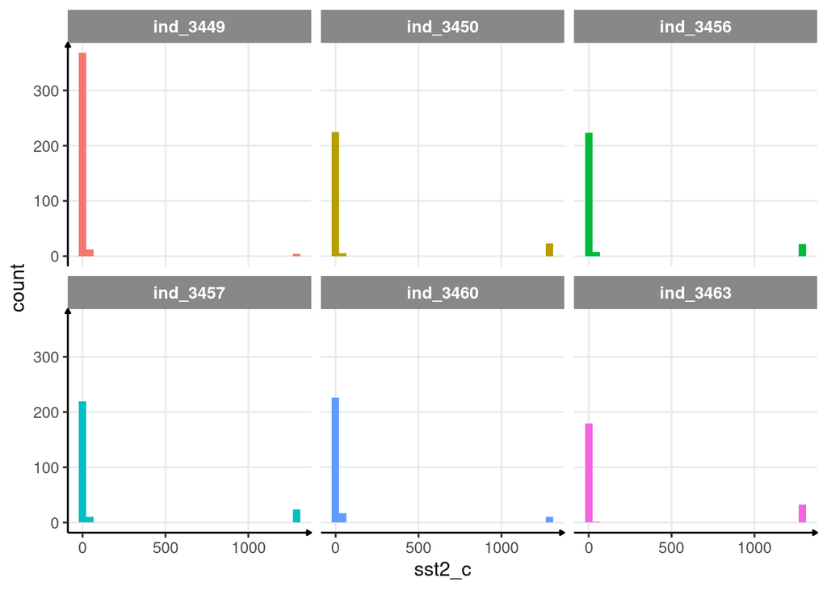

```r
ggplot(data_2016, aes(x = sst2_c, fill = .id)) +
  geom_histogram(show.legend = FALSE) +
  facet_wrap(.id ~ .) +
  theme_jjo()
```

Let’s remove any data with a `sst2_c` > 500.

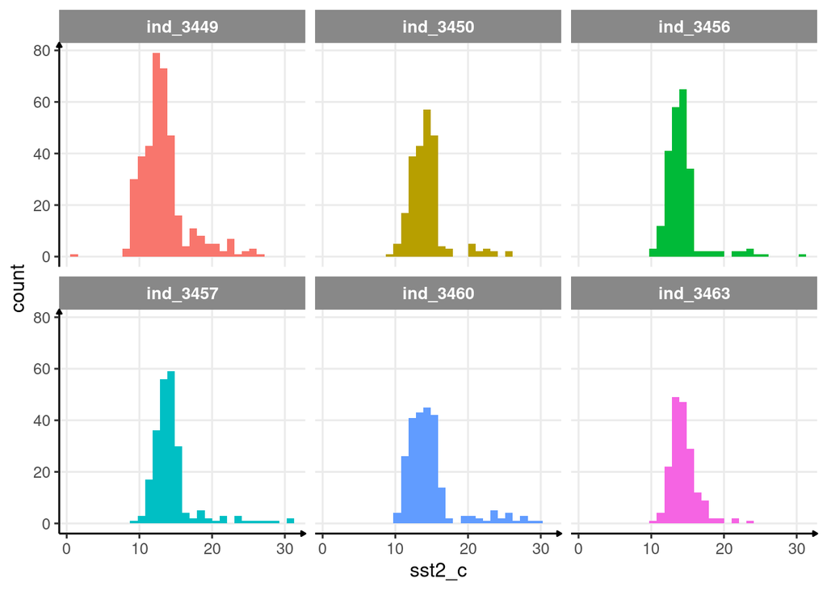

```r
data_2016_filter = data_2016[sst2_c < 500, ]
ggplot(data_2016_filter, aes(x = sst2_c, fill = .id)) +
  geom_histogram(show.legend = FALSE) +
  facet_wrap(.id ~ .) +
  theme_jjo()
```

Well,that seems to be much better! In the process of filtering out odd values, we removed 116 rows this way:

```r
# nbrow removed
data_2016[sst2_c>500,.(nb_row_removed = .N),by=.id] %>%
  sable(caption = "# of rows removed by indivduals")
```

Table 1.3: # of rows removed by indivduals

| .id | nb_row_removed |
| --- | --- |
| ind_3449 | 4 |
| ind_3450 | 23 |
| ind_3456 | 22 |
| ind_3457 | 24 |
| ind_3460 | 10 |
| ind_3463 | 33 |

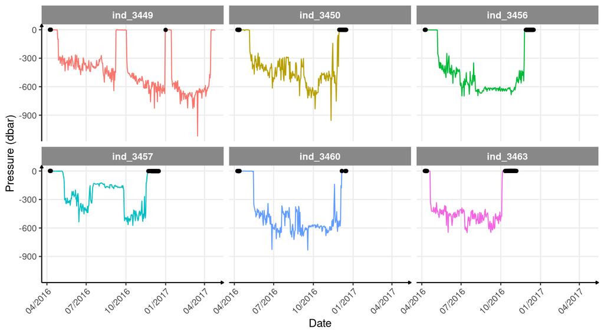

Figure 1.3: Where and when the `sst2` outliers occured

```r
ggplot(data_2016,
       aes(y = -maxpress_dbars, x=as.Date(date), col=.id)) +
  geom_path(show.legend = FALSE) +
  geom_point(data = data_2016[sst2_c>500,], col="black") +
  scale_x_date(date_labels = "%m/%Y") +
  labs(y="Pressure (dbar)", x="Date") +
  facet_wrap(.id ~ .) +
  theme_jjo() +
  theme(axis.text.x = element_text(angle = 45, hjust=1))
```

Well this latter plot highlights several points:

- most of the outliers occur while animals spend the whole day at the surface (or on the ground), probably resting, so essentially at the beginning and the end of each track
- we can already see that `ind_3449` seems to have return ashore twice during his track

Let’s see if we can double check that using some maps.

```r
# interactive map
leaflet() %>%
  setView(lng = -122, lat = 38, zoom = 2) %>%
  addTiles() %>%
  addPolylines(lat = data_2016[.id == "ind_3449", latitude_degs],
               lng = data_2016[.id == "ind_3449", longitude_degs],
               weight = 2) %>%
  addCircleMarkers(lat = data_2016[.id == "ind_3449" & sst2_c>500, latitude_degs],
                   lng = data_2016[.id == "ind_3449" & sst2_c>500, longitude_degs],
                   radius = 3,
                   stroke=FALSE,
                   color="red",
                   fillOpacity=1)
```

[interactive chart not shown]

Figure 1.4: It is supposed to be the track of `ind_3449`… (red dots are the location of removed rows)

… these coordinates seem weird !

```r
# summary of the coordinates by individuals
data_2016[, .(.id, longitude_degs, latitude_degs)] %>%
  tbl_summary(by = .id) %>%
  modify_caption("Summary of `longitude_degree` and `latitude_degree`")
```

Table 1.4: Summary of `longitude_degree` and `latitude_degree`

| **Characteristic** | **ind_3449**, N = 384<sup>1</sup> | **ind_3450**, N = 253<sup>1</sup> | **ind_3456**, N = 253<sup>1</sup> | **ind_3457**, N = 253<sup>1</sup> | **ind_3460**, N = 253<sup>1</sup> | **ind_3463**, N = 213<sup>1</sup> |
| --- | --- | --- | --- | --- | --- | --- |
| longitude_degs | -119 (-132, -69) | -124 (-144, -99) | -112 (-134, -6) | -122 (-132, -97) | -122 (-144, -85) | -121 (-134, -93) |
| latitude_degs | 39 (-67, 68) | 60 (-63, 68) | 56 (-63, 68) | 44 (-63, 68) | 59 (-63, 68) | 63 (42, 72) |

<sup>*1*</sup> Median (IQR)

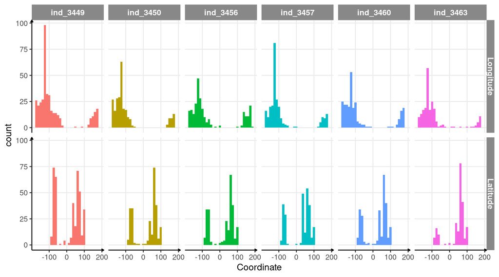

Figure 1.5: Distribution of coordinates per seal

```r
# distribution coordinates
ggplot(
  data = melt(data_2016[, .(Longitude = longitude_degs,
                            Latitude = latitude_degs,
                            .id)], id.vars =
                ".id", value.name = "Coordinate"),
  aes(x = Coordinate, fill = .id)
) +
  geom_histogram(show.legend = F) +
  facet_grid(variable ~ .id) +
  theme_jjo()
```

- For `longitude` a part of the data seems to have the wrong sign, resulting in these distribution that appear to be cut off
- For `latitude`, well this is ensure but maybe the same problem occur

Let’s try to play on coordinates’ sign to see if we can display something that makes more sense.

```r
# interactive map
leaflet() %>%
  setView(lng = -122, lat = 50, zoom = 3) %>%
  addTiles() %>%
  addPolylines(lat = data_2016[.id == "ind_3449", abs(latitude_degs)],
               lng = data_2016[.id == "ind_3449", -abs(longitude_degs)],
               weight = 2)
```

[interactive chart not shown]

Figure 1.6: An attempt to display the `ind_3449`’s track

> I’ll better ask Roxanne!

# 2 2018-individuals

Let’s have a look at what’s inside `data_nes$data_2018`:

```r
# list structure
str(data_nes$year_2018, max.level = 1, give.attr = F, no.list = T)
```

```
##  $ ind_2018070:Classes 'data.table' and 'data.frame':    22393 obs. of  41 variables:
##  $ ind_2018072:Classes 'data.table' and 'data.frame':    29921 obs. of  41 variables:
##  $ ind_2018074:Classes 'data.table' and 'data.frame':    38608 obs. of  41 variables:
##  $ ind_2018080:Classes 'data.table' and 'data.frame':    19028 obs. of  41 variables:
```

```r
# combine all individuals
data_2018 = rbindlist(data_nes$year_2018, use.name = TRUE, idcol = TRUE)

# display
DT::datatable(data_2018[sample.int(.N,100),],options=list(scrollX=T))
```

|  | .id | divenumber | year | month | day | hour | min | sec | juldate | maxdepth | dduration | botttime | desctime | descrate | asctime | ascrate | pdi | dwigglesdesc | dwigglesbott | dwigglesasc | totvertdistbot | bottrange | efficiency | idz | lightatbott | lwiggles | lightatsurf | lattenuation | euphoticdepth | … |
| --- | --- | --- | --- | --- | --- | --- | --- | --- | --- | --- | --- | --- | --- | --- | --- | --- | --- | --- | --- | --- | --- | --- | --- | --- | --- | --- | --- | --- | --- | --- |
| 1 | ind_2018072 | 1102 | 2018 | 5 | 14 | 3 | 16 | 0 | 737194.1361 | 295 | 664 | 208 | 216 | 0.977 | 240 | 1.2 | 56 | 1 | 3 | 1 | 108 | 84 | 0.289 | 1 | 44.148 | 3 | 149 |  |  | … |
| 2 | ind_2018074 | 3883 | 2018 | 6 | 1 | 18 | 5 | 28 | 737212.7538 | 219 | 688 | 240 | 216 | 0.9 | 232 | 0.935 | 64 | 1 | 7 | 1 | 33.5 | 24.5 | 0.319 | 1 | 95.065 | 11 | 156 |  |  | … |
| 3 | ind_2018074 | 4037 | 2018 | 6 | 2 | 18 | 41 | 4 | 737213.7785 | 195.5 | 824 | 520 | 136 | 0.724 | 168 | 1.045 | 80 | 1 | 1 | 1 | 117 | 97 | 0.575 | 1 | 91.5 | 43 | 147 |  |  | … |
| 4 | ind_2018072 | 16042 | 2018 | 10 | 12 | 8 | 0 | 48 | 737345.3339 | 397 | 752 | 104 | 344 | 1.154 | 304 | 1.125 | 80 | 1 | 3 | 5 | 67 | 61 | 0.125 | 1 | 22.643 | 3 | 47 |  |  | … |
| 5 | ind_2018070 | 2593 | 2018 | 5 | 31 | 20 | 38 | 44 | 737211.8602 | 221 | 592 | 256 | 192 | 1.052 | 144 | 1.264 | 64 | 1 | 9 | 1 | 100 | 39.5 | 0.39 | 1 | 107.242 | 15 |  |  | 1.6 | … |
| 6 | ind_2018074 | 4668 | 2018 | 6 | 7 | 2 | 42 | 8 | 737218.1126 | 529 | 840 | 136 | 368 | 1.383 | 336 | 1.482 | 120 | 1 | 5 | 1 | 90 | 36.5 | 0.142 | 1 | 28.111 | 1 | 173.5 | -0.621 | 6.8 | … |
| 7 | ind_2018070 | 11610 | 2018 | 8 | 20 | 10 | 25 | 40 | 737292.4345 | 212 | 560 | 216 | 144 | 1.142 | 200 | 0.782 | 64 | 1 | 9 | 5 | 151 | 70 | 0.346 | 1 | 36.25 | 5 | 32 |  |  | … |
| 8 | ind_2018074 | 34171 | 2019 | 3 | 13 | 22 | 48 | 56 | 737497.9506 | 424.5 | 816 | 232 | 248 | 1.306 | 336 | 1.263 | 104 | 1 | 5 | 1 | 115.5 | 100.5 | 0.252 | 1 | 32.3 | 1 | 188 |  |  | … |
| 9 | ind_2018070 | 14598 | 2018 | 9 | 23 | 6 | 23 | 32 | 737326.2663 | 206.5 | 672 | 280 | 240 | 0.86 | 152 | 1.076 | 80 | 3 | 7 | 3 | 224 | 100.5 | 0.372 | 0 | 24.722 | 1 | 65 |  |  | … |
| 10 | ind_2018074 | 32174 | 2019 | 2 | 20 | 6 | 43 | 4 | 737476.2799 | 409.5 | 704 | 128 | 312 | 1.313 | 264 | 1.422 | 80 | 3 | 9 | 1 | 62 | 37 | 0.163 | 1 | 24.176 | 1 | 79 |  |  | … |

[output cut: 90 more lines]

## 2.1 Summary

```r
# raw_data
data_2018[, .(
  nb_days_recorded = uniqueN(as.Date(date)),
  nb_dives = .N,
  maxdepth_mean = mean(maxdepth),
  dduration_mean = mean(dduration),
  botttime_mean = mean(botttime),
  pdi_mean = mean(pdi, na.rm=T)
), by =.id] %>%
  sable(caption="Summary diving information relative to each 2018 individual",
        digits=2)
```

Table 2.1: Summary diving information relative to each 2018 individual

| .id | nb_days_recorded | nb_dives | maxdepth_mean | dduration_mean | botttime_mean | pdi_mean |
| --- | --- | --- | --- | --- | --- | --- |
| ind_2018070 | 232 | 22393 | 305.52 | 783.27 | 243.22 | 109.55 |
| ind_2018072 | 342 | 29921 | 357.86 | 876.96 | 278.02 | 104.90 |
| ind_2018074 | 371 | 38608 | 250.67 | 686.25 | 291.89 | 302.77 |
| ind_2018080 | 215 | 19028 | 296.50 | 867.69 | 339.90 | 103.51 |

> Very nice dataset :)